# ENEM 2021: Ciências da Natureza

Patricia Livrari

Julho, 2022

```r
if (!requireNamespace('pacman', quietly=TRUE)) install.packages('pacman')

pacman::p_load(data.table,
               tibble,
               parallel,
               stringr,
               tidyr,
               ggplot2,
               patchwork,
               haven)
```

# Lendo os dados

```r
## gov.br/inep/pt-br/acesso-a-informacao/dados-abertos/microdados/enem
dat <- data.table::fread(file  ='~/Downloads/MICRODADOS_ENEM_2021.csv',
                         select=c('TP_PRESENCA_CN',
                                  'CO_PROVA_CN',
                                  'NU_NOTA_CN',
                                  'TX_RESPOSTAS_CN',
                                  'TX_GABARITO_CN'))
(n <- nrow(dat))
```

```
[1] 2685053
```

```r
dat <- dat|>
    dplyr::filter(TP_PRESENCA_CN == 1)|>
    dplyr::select(!TP_PRESENCA_CN)|>
    tibble::as_tibble()
```

```r
dplyr::filter(dat, NU_NOTA_CN == 0)|>nrow()
```

```
[1] 319
```

```r
dplyr::filter(dat, NU_NOTA_CN < 310)|>nrow()
```

```
[1] 319
```

```r
dat <- dplyr::filter(dat, !NU_NOTA_CN < 310)

(ncn <- nrow(dat))
```

```
[1] 1940384
```

```r
dat$CO_PROVA_CN <- as.character(factor(
    dat$CO_PROVA_CN,
    levels=c(909, 910, 911, 912, 915, 916, 917, 989, 990, 991, 992, 996,
             1011, 1012, 1013, 1014, 1045, 1046, 1047, 1048, 1052),
    labels=c('Azul','Amarela','Cinza',
             'Rosa','Laranja - Braille',
             'Laranja - Adaptada Ledor',
             'Verde - Videoprova - Libras',
             'Azul (Reaplicação)',
             'Amarela (Reaplicação)',
             'Cinza (Reaplicação)',
             'Rosa (Reaplicação)',
             'Laranja - Adaptada Ledor (Reaplicação)',
             'Azul (Digital)',
             'Amarela (Digital)',
             'Rosa (Digital)',
             'Cinza (Digital)',
             'Azul (Segunda oportunidade)',
             'Amarela (Segunda oportunidade)',
             'Cinza (Segunda oportunidade)',
             'Rosa (Segunda oportunidade)',
             'Laranja - Adaptada Ledor (Segunda oportunidade)')
))
```

```r
dat
```

```
# A tibble: 1,940,384 × 4
   CO_PROVA_CN    NU_NOTA_CN TX_RESPOSTAS_CN                               TX_GABARITO_CN
   <chr>               <dbl> <chr>                                         <chr>
 1 Rosa                 506. DCBCCBDBCCCCCCDDCDCCCACCABCCECCCCAADCCCBBCADE DABCEDEBEEBBCABEDDCBCBEC…
 2 Cinza                581. CCABBDAEDBEBEDDCAAABBDAADBDCACACEDAABCEABAEBC CDBBBCABEDEDEAAEBACCCBDA…
 3 Rosa                 498. BABCDCCBEBCD.DEDCABCBDEDAABEDADBDBCDECCAEDBCB DABCEDEBEEBBCABEDDCBCBEC…
 4 Amarela              487. BBBDCCBDCCEDBBBCACEBCDADEEADCDEBEDDEBBEBEEECB ADCDCDBBBECDCCDCBCBDABCA…
 5 Azul                 508. BAEDEBDECCEAEDDCBDEDAEECEEEDBDECBDCECBCCDABED EDECABEDABCBEBACCDCBBEEB…
 6 Azul                 651. ECECABECABCDEBECBDCDBEECCDECEAEDBCDCCDBCDACAD EDECABEDABCBEBACCDCBBEEB…
 7 Amarela              378. ACEEDBCCBACEDEADACBEAEBDBABCADBEBACAEACBDCEBD ADCDCDBBBECDCCDCBCBDABCA…
 8 Azul (Digital)       538. EEDCCBEEABCEBACCCACABEADEDDDEDACDBEDCDAACDBAB EDECABEDABCBEBACCDCBBEEB…
 9 Cinza                462. CDBADCBABDBBEBDCAEBDDDBDEDACABADDCBBBCBDDEABB CDBBBCABEDEDEAAEBACCCBDA…
10 Cinza                488. CDCDDAEBDEBABECEACDAAEBAECAEADDBCDDADEAABECDA CDBBBCABEDEDEAAEBACCCBDA…
# … with 1,940,374 more rows
```

# Respostas

```r
resposta <-
    parallel::mclapply(
                  seq(ncn),
                  function(i)
                      unlist(
                          stringr::str_split(dat$TX_RESPOSTAS_CN[i], '')
                      )
              )
resposta           <- t(simplify2array(resposta))
colnames(resposta) <- paste0('Q', seq(45))
resposta           <- tibble::as_tibble(resposta)

str(resposta)
```

```
tibble [1,940,384 × 45] (S3: tbl_df/tbl/data.frame)
 $ Q1 : chr [1:1940384] "D" "C" "B" "B" ...
 $ Q2 : chr [1:1940384] "C" "C" "A" "B" ...
 $ Q3 : chr [1:1940384] "B" "A" "B" "B" ...
 $ Q4 : chr [1:1940384] "C" "B" "C" "D" ...
 $ Q5 : chr [1:1940384] "C" "B" "D" "C" ...
 $ Q6 : chr [1:1940384] "B" "D" "C" "C" ...
 $ Q7 : chr [1:1940384] "D" "A" "C" "B" ...
 $ Q8 : chr [1:1940384] "B" "E" "B" "D" ...
 $ Q9 : chr [1:1940384] "C" "D" "E" "C" ...
 $ Q10: chr [1:1940384] "C" "B" "B" "C" ...
 $ Q11: chr [1:1940384] "C" "E" "C" "E" ...
 $ Q12: chr [1:1940384] "C" "B" "D" "D" ...
 $ Q13: chr [1:1940384] "C" "E" "." "B" ...
 $ Q14: chr [1:1940384] "C" "D" "D" "B" ...
```

[output cut: 31 more lines]

# Gabarito

```r
gabarito <-
    parallel::mclapply(
                  seq(ncn),
                  function(i)
                      unlist(
                          stringr::str_split(dat$TX_GABARITO_CN[i], '')
                      )
              )
gabarito           <- t(simplify2array(gabarito))
colnames(gabarito) <- paste0('Q', seq(45))
gabarito           <- tibble::as_tibble(gabarito)

str(gabarito)
```

```
tibble [1,940,384 × 45] (S3: tbl_df/tbl/data.frame)
 $ Q1 : chr [1:1940384] "D" "C" "D" "A" ...
 $ Q2 : chr [1:1940384] "A" "D" "A" "D" ...
 $ Q3 : chr [1:1940384] "B" "B" "B" "C" ...
 $ Q4 : chr [1:1940384] "C" "B" "C" "D" ...
 $ Q5 : chr [1:1940384] "E" "B" "E" "C" ...
 $ Q6 : chr [1:1940384] "D" "C" "D" "D" ...
 $ Q7 : chr [1:1940384] "E" "A" "E" "B" ...
 $ Q8 : chr [1:1940384] "B" "B" "B" "B" ...
 $ Q9 : chr [1:1940384] "E" "E" "E" "B" ...
 $ Q10: chr [1:1940384] "E" "D" "E" "E" ...
 $ Q11: chr [1:1940384] "B" "E" "B" "C" ...
 $ Q12: chr [1:1940384] "B" "D" "B" "D" ...
 $ Q13: chr [1:1940384] "C" "E" "C" "C" ...
 $ Q14: chr [1:1940384] "A" "A" "A" "C" ...
```

[output cut: 31 more lines]

# Análise Descritiva

## NU_NOTA_CN

> Nota na prova.

```r
(nota <- rbind(
     with(dat, c(summary(NU_NOTA_CN), 'Std. Dev.'=sd(NU_NOTA_CN)))
 )|>
     tibble::as_tibble())
```

```
# A tibble: 1 × 7
   Min. `1st Qu.` Median  Mean `3rd Qu.`  Max. `Std. Dev.`
  <dbl>     <dbl>  <dbl> <dbl>     <dbl> <dbl>       <dbl>
1  310.      431.   482.  493.      548.  867.        81.3
```

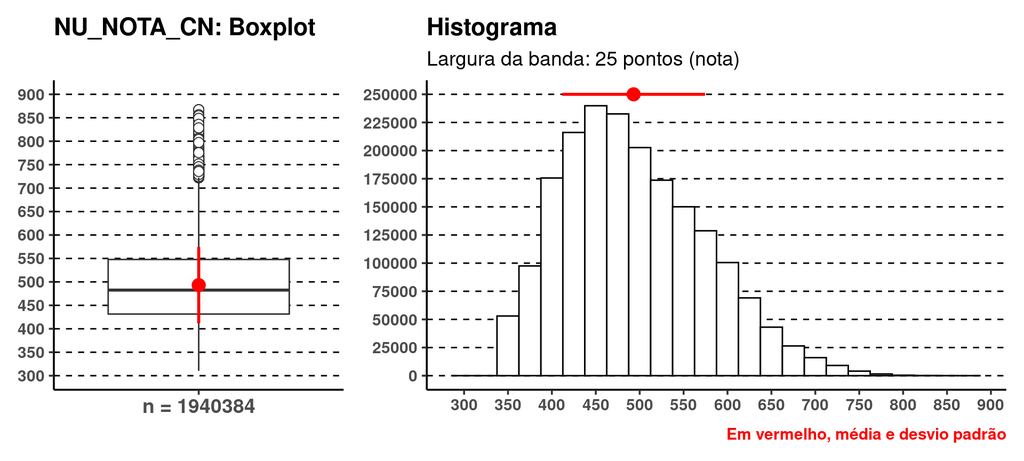

```r
p1 <- ggplot()+
    geom_hline(yintercept=seq(300, 900, by=50), linetype='dashed')+
    geom_boxplot(data=dat,
                 aes(x=paste('n =', ncn), y=NU_NOTA_CN),
                 outlier.size=3, outlier.shape=21)+
    geom_linerange(mapping=aes(x   =1,
                               ymin=nota$Mean-nota$`Std. Dev.`,
                               ymax=nota$Mean+nota$`Std. Dev.`),
                   color='#ff0000', size=1)+
    geom_point(mapping=aes(x=1, y=nota$Mean), color='#ff0000', size=4)+
    scale_y_continuous(breaks=seq(300, 900, by=50))+
    labs(x=NULL, y=NULL, title='NU_NOTA_CN: Boxplot')+
    theme_classic(base_size=14)+
    theme(plot.title   =element_text(face='bold'),
          plot.subtitle=element_text(face='bold', color='#ff0000'),
          axis.text.x  =element_text(face='bold', size=14),
          axis.text.y  =element_text(face='bold'))

p2 <- ggplot()+
    geom_hline(yintercept=seq(0, 2.5e5, by=25e3), linetype='dashed')+
    geom_histogram(data=dat,
                   aes(x=NU_NOTA_CN),
                   binwidth=25, color='black', fill='white')+
    geom_linerange(mapping=aes(xmin=nota$Mean-nota$`Std. Dev.`,
                               xmax=nota$Mean+nota$`Std. Dev.`,
                               y   =2.5e5),
                   color='#ff0000', size=1)+
    geom_point(mapping=aes(x=nota$Mean, y=2.5e5),
               color='#ff0000', size=4)+
    scale_x_continuous(breaks=seq(300, 900, by=50))+
    scale_y_continuous(breaks=seq(0, 2.5e5, by=25e3))+
    labs(x       =NULL,
         y       =NULL,
         title   ='Histograma',
         subtitle='Largura da banda: 25 pontos (nota)',
         caption ='Em vermelho, média e desvio padrão')+
    theme_classic(base_size=14)+
    theme(plot.title  =element_text(face='bold'),
          axis.text.x =element_text(face='bold'),
          axis.text.y =element_text(face='bold'),
          plot.caption=element_text(face='bold', color='#ff0000'))

p1 + p2 + patchwork::plot_layout(widths=c(0.5, 1))
```

## CO_PROVA_CN

> Tipo de prova.

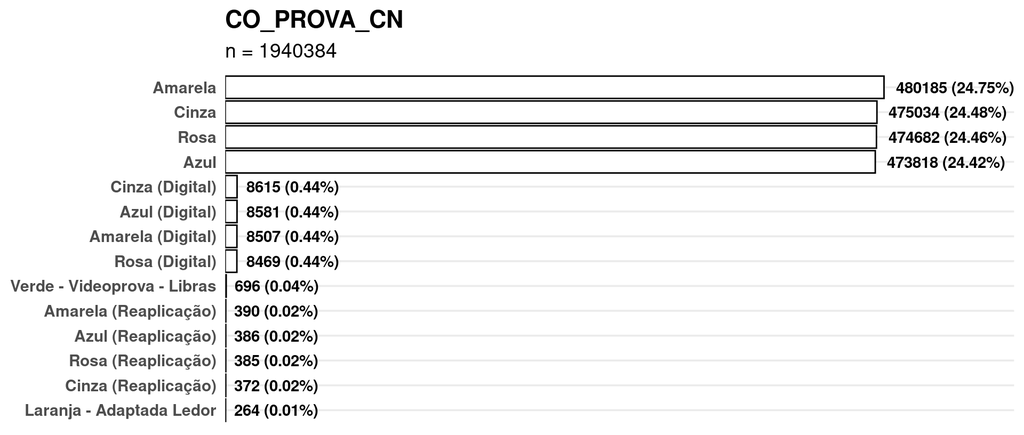

```r
dat|>
    dplyr::count(CO_PROVA_CN)|>
    dplyr::arrange(n)|>
    dplyr::mutate(CO_PROVA_CN=haven::as_factor(CO_PROVA_CN))|>
    ggplot(aes(x=n, y=CO_PROVA_CN))+
    geom_col(col='black', fill='white')+
    geom_text(aes(label=paste0(n, ' (', round(100*n/ncn, 2), '%)')),
              hjust=-0.1, fontface='bold')+
    scale_x_continuous(expand=c(0, 0),
                       breaks=NULL, limits=c(0, 5.75e5))+
    labs(x       =NULL,
         y       =NULL,
         title   ='CO_PROVA_CN',
         subtitle=paste('n =', ncn))+
    theme_minimal(base_size=14)+
    theme(plot.title =element_text(face='bold'),
          axis.text.y=element_text(face='bold'))
```

## NU_NOTA_CN por CO_PROVA_CN

> Nota por tipo de prova.

```r
(nota_prova <- dat|>
     dplyr::group_by(CO_PROVA_CN)|>
     dplyr::summarise('Min.'     =min(NU_NOTA_CN),
                      '1st Qu.'  =quantile(NU_NOTA_CN, 0.25),
                      Median     =median(NU_NOTA_CN),
                      Mean       =mean(NU_NOTA_CN),
                      '3rd Qu.'  =quantile(NU_NOTA_CN, 0.75),
                      'Max.'     =max(NU_NOTA_CN),
                      'Std. Dev.'=sd(NU_NOTA_CN)))
```

```
# A tibble: 14 × 8
   CO_PROVA_CN                  Min. `1st Qu.` Median  Mean `3rd Qu.`  Max. `Std. Dev.`
   <chr>                       <dbl>     <dbl>  <dbl> <dbl>     <dbl> <dbl>       <dbl>
 1 Amarela                      340.      433.   483.  493.      547.  867.        80.7
 2 Amarela (Digital)            342.      430.   476.  486.      534.  793.        74.2
 3 Amarela (Reaplicação)        318.      478.   535.  535.      587.  793.        80.1
 4 Azul                         340.      430.   481.  492.      548.  857.        82.0
 5 Azul (Digital)               340.      427.   475.  486.      539.  812.        77.4
 6 Azul (Reaplicação)           328.      461.   527.  526.      592.  727.        88.0
 7 Cinza                        340.      431.   482.  493.      548.  867.        81.5
 8 Cinza (Digital)              340.      428.   476.  486.      536.  789.        76.3
 9 Cinza (Reaplicação)          310.      482    536.  534.      590.  824.        83.9
10 Laranja - Adaptada Ledor     332.      419.   462.  467.      509.  777.        69.2
11 Rosa                         340.      432.   484.  494.      550.  867.        81.3
12 Rosa (Digital)               340.      429.   476.  486.      537.  798.        75.2
13 Rosa (Reaplicação)           336.      483.   538.  536.      586.  771.        81.6
14 Verde - Videoprova - Libras  344.      381.   412.  423.      449.  691         56.7
```

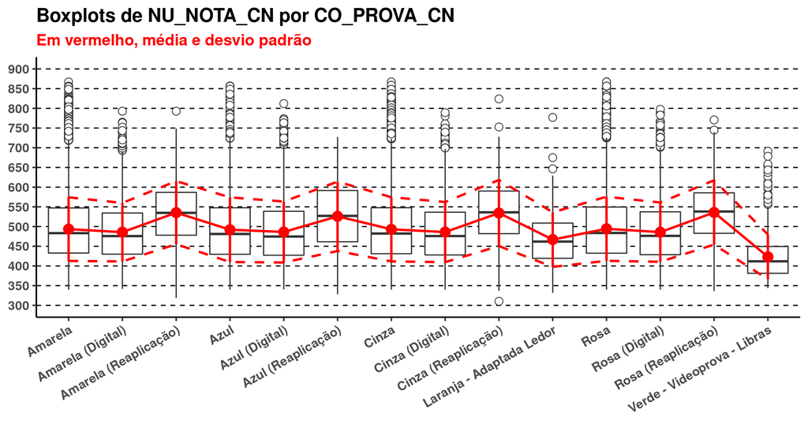

```r
ggplot()+
    geom_hline(yintercept=seq(300, 900, by=50), linetype='dashed')+
    geom_boxplot(data=dat,
                 aes(x=CO_PROVA_CN, y=NU_NOTA_CN),
                 outlier.size=3, outlier.shape=21)+
    geom_linerange(
        mapping=aes(x   =nota_prova$CO_PROVA_CN,
                    ymin=nota_prova$Mean-nota_prova$`Std. Dev.`,
                    ymax=nota_prova$Mean+nota_prova$`Std. Dev.`),
        color='#ff0000', size=1
    )+
    geom_point(mapping=aes(x=nota_prova$CO_PROVA_CN,
                           y=nota_prova$Mean), color='#ff0000', size=4)+
    geom_line(mapping=aes(x    =nota_prova$CO_PROVA_CN,
                          y    =nota_prova$Mean,
                          group=1), color='#ff0000', size=1)+
    geom_line(mapping=aes(x    =nota_prova$CO_PROVA_CN,
                          y    =nota_prova$Mean-nota_prova$`Std. Dev.`,
                          group=1),
              color='#ff0000', size=1, linetype='dashed')+
    geom_line(mapping=aes(x    =nota_prova$CO_PROVA_CN,
                          y    =nota_prova$Mean+nota_prova$`Std. Dev.`,
                          group=1),
              color='#ff0000', size=1, linetype='dashed')+
    scale_y_continuous(breaks=seq(300, 900, by=50))+
    labs(x       =NULL,
         y       =NULL,
         title   ='Boxplots de NU_NOTA_CN por CO_PROVA_CN',
         subtitle='Em vermelho, média e desvio padrão')+
    theme_classic(base_size=14)+
    theme(plot.title   =element_text(face='bold'),
          plot.subtitle=element_text(face='bold', color='#ff0000'),
          axis.text.x  =element_text(face='bold', angle=30, hjust=1),
          axis.text.y  =element_text(face='bold'))
```

## Acertos

> 45 questões. Resposta dada e gabarito.

### Por questão

```r
acertos <- purrr::map_dbl(seq(45),
                          function (i)
                              sum(resposta[, i] == gabarito[, i])
                          )
acertos <- tibble::tibble(Questão=seq(45),
                          acertos, acertos.perc=acertos/ncn)

with(acertos, c(summary(acertos.perc), 'Std. Dev.'=sd(acertos.perc)))
```

```
      Min.    1st Qu.     Median       Mean    3rd Qu.       Max.  Std. Dev.
0.19315867 0.25635750 0.29194582 0.30814517 0.37349978 0.50198157 0.07520607
```

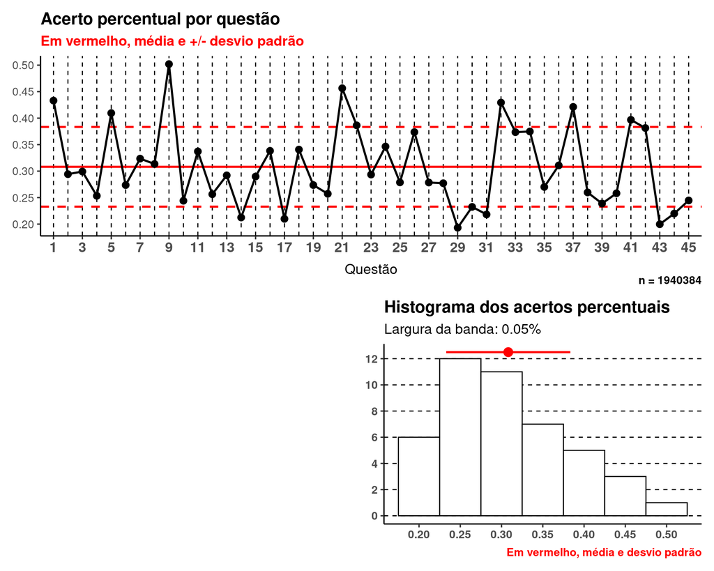

```r
p1 <- acertos|>
    ggplot(aes(x=Questão, y=acertos.perc))+
    geom_vline(xintercept=seq(45), linetype='dashed')+
    geom_hline(yintercept=mean(acertos$acertos.perc),
               color='#ff0000', size=1)+
    geom_hline(
        yintercept=mean(acertos$acertos.perc)-sd(acertos$acertos.perc),
        color='#ff0000', size=1, linetype='dashed'
    )+
    geom_hline(
        yintercept=mean(acertos$acertos.perc)+sd(acertos$acertos.perc),
        color='#ff0000', size=1, linetype='dashed'
    )+
    geom_line(size=1)+
    geom_point(size=3)+
    scale_x_continuous(expand=c(0.02, 0.02), breaks=seq(1, 45, by=2))+
    scale_y_continuous(breaks=seq(0, 1, by=0.05))+
    labs(y       =NULL,
         title   ='Acerto percentual por questão',
         subtitle='Em vermelho, média e +/- desvio padrão',
         caption =paste('n =', ncn))+
    theme_classic(base_size=14)+
    theme(plot.title   =element_text(face='bold'),
          plot.subtitle=element_text(face='bold', color='#ff0000'),
          plot.caption =element_text(face='bold'),
          axis.text.x  =element_text(face='bold', size=14),
          axis.title.x =element_text(
              margin=ggplot2::unit(c(t=3, r=0, b=-3, l=0), 'mm')
          ))

p2 <- ggplot()+
    geom_hline(yintercept=seq(0, 12, by=2), linetype='dashed')+
    geom_histogram(data=acertos,
                   aes(x=acertos.perc),
                   binwidth=0.05, color='black', fill='white')+
    geom_linerange(
        mapping=aes(
            xmin=mean(acertos$acertos.perc)-sd(acertos$acertos.perc),
            xmax=mean(acertos$acertos.perc)+sd(acertos$acertos.perc),
            y   =12.5), color='#ff0000', size=1)+
    geom_point(mapping=aes(x=mean(acertos$acertos.perc), y=12.5),
               color='#ff0000', size=4)+
    scale_x_continuous(breaks=seq(0.15, 0.55, by=0.05))+
    scale_y_continuous(breaks=seq(0, 12, by=2))+
    labs(x       =NULL,
         y       =NULL,
         title   ='Histograma dos acertos percentuais',
         subtitle='Largura da banda: 0.05%',
         caption ='Em vermelho, média e desvio padrão')+
    theme_classic(base_size=14)+
    theme(plot.title  =element_text(face='bold'),
          axis.text.x =element_text(face='bold'),
          axis.text.y =element_text(face='bold'),
          plot.caption=element_text(face='bold', color='#ff0000'))

layout <- '
AA
#B
'
p1 + p2 + patchwork::plot_layout(design=layout)
```

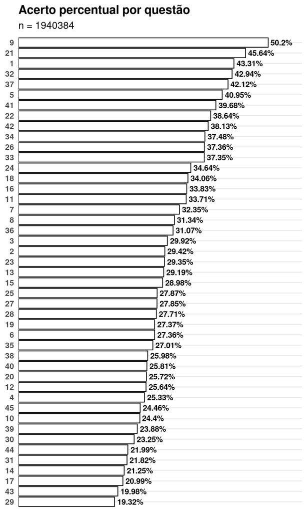

```r
acertos|>
    dplyr::arrange(acertos.perc)|>
    dplyr::mutate(Questão=haven::as_factor(as.character(Questão)))|>
    ggplot(aes(x=acertos.perc, y=Questão))+
    geom_col(col='black', fill='white')+
    geom_text(aes(label=paste0(round(100*acertos.perc, 2), '%')),
              hjust=-0.1, fontface='bold')+
    scale_x_continuous(expand=c(0, 0), breaks=NULL, limits=c(0, 0.57))+
    labs(x       =NULL,
         y       =NULL,
         title   ='Acerto percentual por questão',
         subtitle=paste('n =', ncn))+
    theme_minimal(base_size=14)+
    theme(plot.title =element_text(face='bold'),
          axis.text.y=element_text(face='bold'))
```

### Por ID

```r
acertosid <- purrr::map_dbl(seq(ncn),
                            function (i)
                                sum(resposta[i, ] == gabarito[i, ])
                            )
acertosid <-
    tibble::tibble(Questão=seq(ncn), acertosid, perc=acertosid/45)

with(acertosid, c(summary(perc), 'Std. Dev.'=sd(perc)))
```

```
     Min.   1st Qu.    Median      Mean   3rd Qu.      Max. Std. Dev.
0.0000000 0.2222222 0.2888889 0.3081452 0.3555556 1.0000000 0.1204338
```

```r
with(acertosid, c(summary(acertosid), 'Std. Dev.'=sd(acertosid)))
```

```
     Min.   1st Qu.    Median      Mean   3rd Qu.      Max. Std. Dev.
 0.000000 10.000000 13.000000 13.866533 16.000000 45.000000  5.419521
```

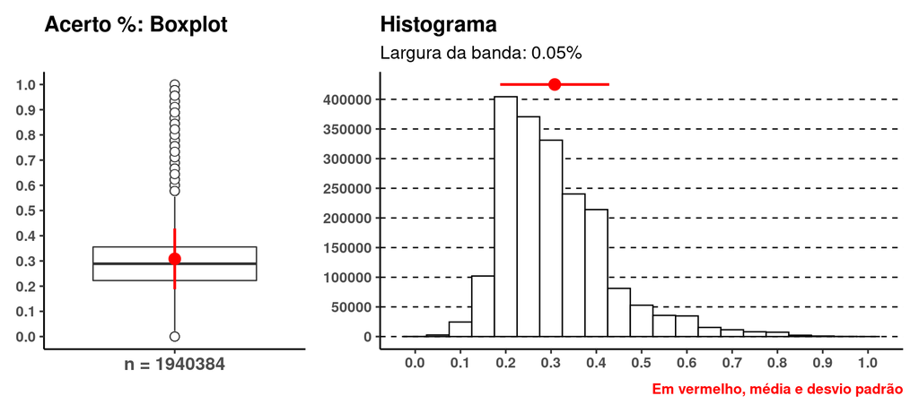

```r
notaid <- rbind(
    with(acertosid, c(summary(perc), 'Std. Dev.'=sd(perc)))
)|>
    tibble::as_tibble()

p1 <- ggplot()+
    ## geom_hline(yintercept=seq(300, 900, by=50), linetype='dashed')+
    geom_boxplot(data=acertosid,
                 aes(x=paste('n =', ncn), y=perc),
                 outlier.size=3, outlier.shape=21)+
    geom_linerange(mapping=aes(x   =1,
                               ymin=notaid$Mean-notaid$`Std. Dev.`,
                               ymax=notaid$Mean+notaid$`Std. Dev.`),
                   color='#ff0000', size=1)+
    geom_point(mapping=aes(x=1, y=notaid$Mean),
               color='#ff0000', size=4)+
    scale_y_continuous(breaks=seq(0, 1, by=0.1))+
    labs(x=NULL, y=NULL, title='Acerto %: Boxplot')+
    theme_classic(base_size=14)+
    theme(plot.title   =element_text(face='bold'),
          plot.subtitle=element_text(face='bold', color='#ff0000'),
          axis.text.x  =element_text(face='bold', size=14),
          axis.text.y  =element_text(face='bold'))

p2 <- ggplot()+
    geom_hline(yintercept=seq(0, 4e5, by=5e4), linetype='dashed')+
    geom_histogram(data=acertosid,
                   aes(x=perc),
                   binwidth=0.05, color='black', fill='white')+
    geom_linerange(mapping=aes(xmin=notaid$Mean-notaid$`Std. Dev.`,
                               xmax=notaid$Mean+notaid$`Std. Dev.`,
                               y   =4.25e5),
                   color='#ff0000', size=1)+
    geom_point(mapping=aes(x=notaid$Mean, y=4.25e5),
               color='#ff0000', size=4)+
    scale_x_continuous(breaks=seq(0, 1, by=0.1))+
    scale_y_continuous(breaks=seq(0, 4e5, by=5e4))+
    labs(x       =NULL,
         y       =NULL,
         title   ='Histograma',
         subtitle='Largura da banda: 0.05%',
         caption ='Em vermelho, média e desvio padrão')+
    theme_classic(base_size=14)+
    theme(plot.title  =element_text(face='bold'),
          axis.text.x =element_text(face='bold'),
          axis.text.y =element_text(face='bold'),
          plot.caption=element_text(face='bold', color='#ff0000'))

p1 + p2 + patchwork::plot_layout(widths=c(0.5, 1))
```

```r
acertosid <- acertosid|>
    dplyr::mutate(CO_PROVA_CN=dat$CO_PROVA_CN)

(acertosid_prova <- acertosid|>
     dplyr::group_by(CO_PROVA_CN)|>
     dplyr::summarise('Min.'     =min(perc),
                      '1st Qu.'  =quantile(perc, 0.25),
                      Median     =median(perc),
                      Mean       =mean(perc),
                      '3rd Qu.'  =quantile(perc, 0.75),
                      'Max.'     =max(perc),
                      'Std. Dev.'=sd(perc)))
```

```
# A tibble: 14 × 8
   CO_PROVA_CN                   Min. `1st Qu.` Median  Mean `3rd Qu.`  Max. `Std. Dev.`
   <chr>                        <dbl>     <dbl>  <dbl> <dbl>     <dbl> <dbl>       <dbl>
 1 Amarela                     0          0.222  0.289 0.308     0.356 0.978      0.120
 2 Amarela (Digital)           0.0444     0.222  0.289 0.298     0.356 0.889      0.106
 3 Amarela (Reaplicação)       0.0889     0.311  0.378 0.422     0.511 0.933      0.157
 4 Azul                        0          0.222  0.289 0.307     0.356 0.978      0.121
 5 Azul (Digital)              0.0222     0.222  0.289 0.299     0.356 0.933      0.113
 6 Azul (Reaplicação)          0.133      0.294  0.378 0.414     0.511 0.867      0.160
 7 Cinza                       0          0.222  0.289 0.307     0.356 1          0.121
 8 Cinza (Digital)             0.0444     0.222  0.289 0.298     0.356 0.911      0.111
 9 Cinza (Reaplicação)         0.111      0.311  0.4   0.427     0.533 0.978      0.160
10 Laranja - Adaptada Ledor    0.111      0.2    0.267 0.271     0.311 0.911      0.101
11 Rosa                        0          0.222  0.289 0.311     0.356 1          0.120
12 Rosa (Digital)              0          0.222  0.289 0.299     0.356 0.911      0.108
13 Rosa (Reaplicação)          0.111      0.311  0.4   0.423     0.489 0.933      0.161
14 Verde - Videoprova - Libras 0.0444     0.178  0.222 0.225     0.267 0.667      0.0783
```

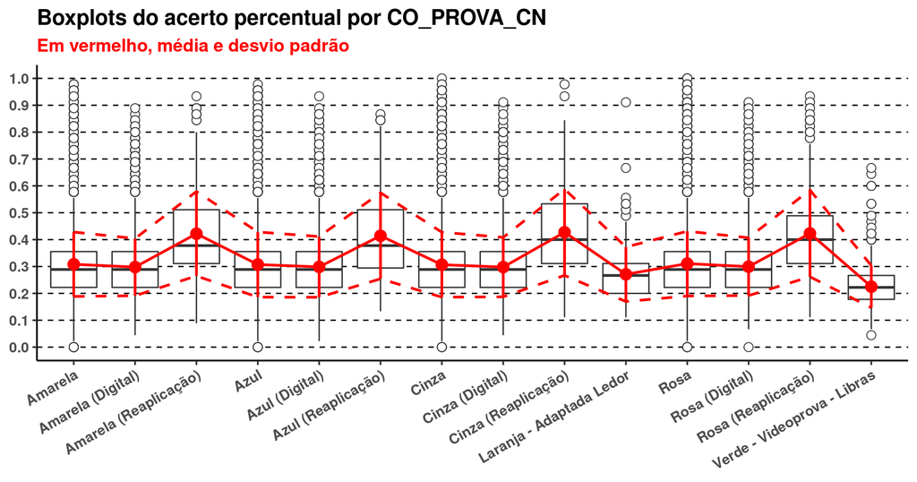

```r
ggplot()+
    geom_hline(yintercept=seq(0, 1, by=0.1), linetype='dashed')+
    geom_boxplot(data=acertosid,
                 aes(x=CO_PROVA_CN, y=perc),
                 outlier.size=3, outlier.shape=21)+
    geom_linerange(
        mapping=aes(
            x   =acertosid_prova$CO_PROVA_CN,
            ymin=acertosid_prova$Mean-acertosid_prova$`Std. Dev.`,
            ymax=acertosid_prova$Mean+acertosid_prova$`Std. Dev.`
        ), color='#ff0000', size=1
    )+
    geom_point(mapping=aes(x=acertosid_prova$CO_PROVA_CN,
                           y=acertosid_prova$Mean),
               color='#ff0000', size=4)+
    geom_line(mapping=aes(x    =acertosid_prova$CO_PROVA_CN,
                          y    =acertosid_prova$Mean,
                          group=1), color='#ff0000', size=1)+
    geom_line(
        mapping=aes(
            x    =acertosid_prova$CO_PROVA_CN,
            y    =acertosid_prova$Mean-acertosid_prova$`Std. Dev.`,
            group=1),
        color='#ff0000', size=1, linetype='dashed')+
    geom_line(
        mapping=aes(
            x    =acertosid_prova$CO_PROVA_CN,
            y    =acertosid_prova$Mean+acertosid_prova$`Std. Dev.`,
            group=1),
        color='#ff0000', size=1, linetype='dashed')+
    scale_y_continuous(breaks=seq(0, 1, by=0.1))+
    labs(x       =NULL,
         y       =NULL,
         title   ='Boxplots do acerto percentual por CO_PROVA_CN',
         subtitle='Em vermelho, média e desvio padrão')+
    theme_classic(base_size=14)+
    theme(plot.title   =element_text(face='bold'),
          plot.subtitle=element_text(face='bold', color='#ff0000'),
          axis.text.x  =element_text(face='bold', angle=30, hjust=1),
          axis.text.y  =element_text(face='bold'))
```

```r
## dat_long <-
##     dplyr::bind_rows(
##                tibble::tibble(
##                            type='Resposta',
##                            tidyr::pivot_longer(
##                                       cbind(CO_PROVA_CN=dat$CO_PROVA_CN,
##                                             resposta), Q1:Q45)),
##                tibble::tibble(
##                            type='Gabarito',
##                            tidyr::pivot_longer(
##                                       cbind(CO_PROVA_CN=dat$CO_PROVA_CN,
##                                             gabarito), Q1:Q45)))
## str(dat_long)
```

# Referências

> R Core Team (2022). R: A language and environment for statistical computing. R Foundation for Statistical Computing, Vienna, Austria. URL https://www.R-project.org/

> Dowle, M., Srinivasan, A. (2021). data.table: Extension of `data.frame`. R package version 1.14.2, https://CRAN.R-project.org/package=data.table

> Müller, K., Wickham, H. (2022). tibble: Simple Data Frames. R package version 3.1.7, https://CRAN.R-project.org/package=tibble

> Wickham, H. (2019). stringr: Simple, Consistent Wrappers for Common String Operations. R package version 1.4.0, https://CRAN.R-project.org/package=stringr

> Wickham, H., Girlich, M. (2022). tidyr: Tidy Messy Data. R package version 1.2.0, https://CRAN.R-project.org/package=tidyr

> Wickham, H. (2016). ggplot2: Elegant Graphics for Data Analysis. Springer-Verlag New York

> Pedersen, T. (2020). patchwork: The Composer of Plots. R package version 1.1.1, https://CRAN.R-project.org/package=patchwork

> Wickham, H., Miller, E., Smith, D. (2022). haven: Import and Export ‘SPSS’,‘Stata’ and ‘SAS’ Files. R package version 2.5.0, https://CRAN.R-project.org/package=haven